# Final_Project

Miaoxi Wang

4/29/2018

# Data Cleansing

The data contain some missing values, like NA???s or blank strings. So I changed few variables into some other datatype like price to a numeric type, and decription to a character type.

```r
file<- "~/Desktop/DW_Project/listings.csv"
listings <- read_csv("~/Desktop/DW_Project/listings.csv")
listings_clean<- read.csv(file, na.strings=c(""," ","NA"))
listings_clean$price <- as.numeric(sub("\\$","", listings_clean$price))
listings_clean$description <- as.character(listings_clean$description)
listings_clean$neighbourhood_cleansed <- factor(listings_clean$neighbourhood_cleansed)
listings_clean$host_is_superhost <- factor(listings_clean$host_is_superhost)
```

# Tring to find the lower quartile, median and upper quartile of NY airbnb price.

Median=$100, upper quartile > $168

```
##     0%     1%     2%     3%     4%     5%     6%     7%     8%     9%
##   0.00  29.00  32.00  35.00  38.00  40.00  40.00  44.00  45.00  45.00
##    10%    11%    12%    13%    14%    15%    16%    17%    18%    19%
##  48.00  49.00  50.00  50.00  50.00  53.00  55.00  55.00  58.00  59.00
##    20%    21%    22%    23%    24%    25%    26%    27%    28%    29%
##  60.00  60.00  60.00  65.00  65.00  65.00  68.00  69.00  70.00  70.00
##    30%    31%    32%    33%    34%    35%    36%    37%    38%    39%
##  72.00  75.00  75.00  75.00  79.00  80.00  80.00  80.00  85.00  85.00
##    40%    41%    42%    43%    44%    45%    46%    47%    48%    49%
##  88.00  90.00  90.00  90.00  95.00  95.00  99.00  99.00 100.00 100.00
##    50%    51%    52%    53%    54%    55%    56%    57%    58%    59%
## 100.00 100.00 104.00 109.00 110.00 112.00 115.00 120.00 120.00 120.00
##    60%    61%    62%    63%    64%    65%    66%    67%    68%    69%
## 125.00 125.00 129.00 130.00 135.00 139.00 140.00 145.00 149.00 150.00
##    70%    71%    72%    73%    74%    75%    76%    77%    78%    79%
## 150.00 150.00 150.00 159.00 160.00 168.00 174.00 175.00 180.00 181.00
##    80%    81%    82%    83%    84%    85%    86%    87%    88%    89%
## 190.00 195.00 199.00 200.00 200.00 200.00 219.00 225.00 235.00 250.00
##    90%    91%    92%    93%    94%    95%    96%    97%    98%    99%
## 250.00 255.63 275.00 299.00 300.00 330.00 350.00 400.00 475.00 599.00
##   100%
## 999.00
```

summary stat of price

```
##    Min. 1st Qu.  Median    Mean 3rd Qu.    Max.    NA's
##     0.0    65.0   100.0   134.7   168.0   999.0     258
```

# Sentiment analysis of top 10 neignbourhood in New York area

top 10 neignbourhood

```
## # A tibble: 10 x 2
##    neighbourhood_cleansed count
##    <fct>                  <int>
##  1 Williamsburg            4325
##  2 Bedford-Stuyvesant      3571
##  3 Harlem                  2884
##  4 Bushwick                2489
##  5 East Village            2096
##  6 Upper West Side         2037
##  7 Hell's Kitchen          1869
##  8 Upper East Side         1783
##  9 Crown Heights           1687
## 10 Midtown                 1279
```

filtering listings of top 10 neighbourhood and unnest words, then get word-sentiment lexicon, and count words associate with each type of sentiment in each neighbourhood

plot the sentiment in Top 10 Neighbourhoods

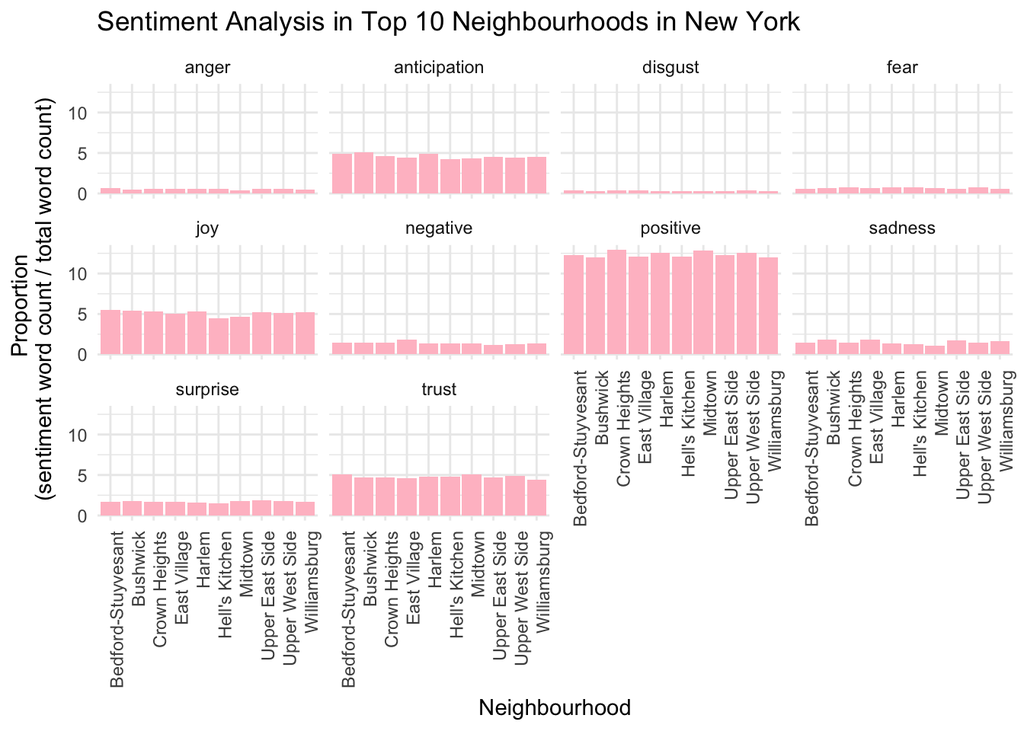

# Sentiment Analysis the sentiment by property type in New York area

[figure not shown]

#In this part I tried to find the common words used in room descriptions so I plot the most 15 words used in Upper quantile and Lower quantile listings

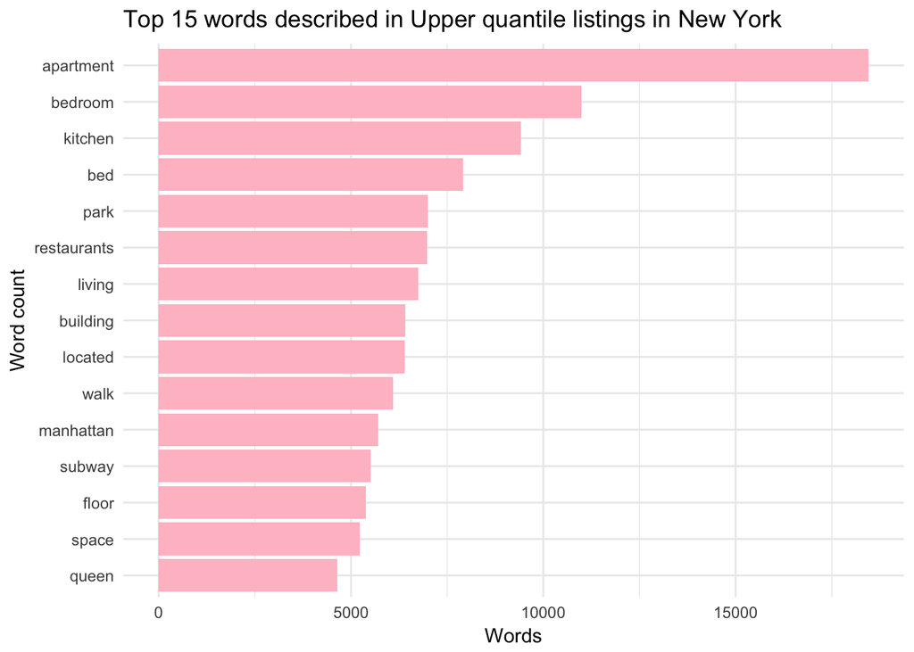

# the most common words in lower quartile

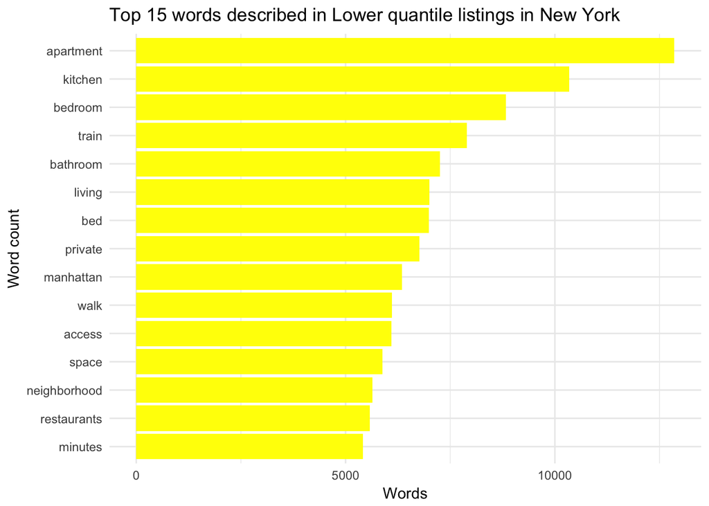